# Biostat 203B Homework 4

Due Mar 8 @ 11:59PM

Author

Li Zhang 206305918

Display machine information:

Display my machine memory.

```r
memuse::Sys.meminfo()
```

```
Totalram:   8.000 GiB
Freeram:   70.312 MiB
```

Load database libraries and the tidyverse frontend:

```r
library(bigrquery)
library(dbplyr)
library(DBI)
library(gt)
library(gtsummary)
library(tidyverse)
library(magrittr)
```

## Q1. Compile the ICU cohort in HW3 from the Google BigQuery database

Below is an outline of steps. In this homework, we exclusively work with the BigQuery database and should not use any MIMIC data files stored on our local computer. Transform data as much as possible in BigQuery database and `collect()` the tibble only at the end of Q1.7.

### Q1.1 Connect to BigQuery

Authenticate with BigQuery using the service account token. Please place the service account token (shared via BruinLearn) in the working directory (same folder as your qmd file). Do **not** add this token to your git repository.

```r
# path to the service account token
satoken <- "biostat-203b-2024-winter-313290ce47a6.json"
# BigQuery authentication using service account
bq_auth(path = satoken)
```

Connect to BigQuery database `mimic4_v2_2` in GCP (Google Cloud Platform), using the project billing account `biostat-203b-2024-winter`.

```r
# connect to the BigQuery database `biostat-203b-2024-winter.mimic4_v2_2`
con_bq <- dbConnect(
    bigrquery::bigquery(),
    project = "biostat-203b-2024-winter",
    dataset = "mimic4_v2_2",
    billing = "biostat-203b-2024-winter"
)
con_bq
```

```
<BigQueryConnection>
  Dataset: biostat-203b-2024-winter.mimic4_v2_2
  Billing: biostat-203b-2024-winter
```

List all tables in the `mimic4_v2_2` database.

```r
dbListTables(con_bq)
```

```
 [1] "admissions"         "caregiver"          "chartevents"
 [4] "d_hcpcs"            "d_icd_diagnoses"    "d_icd_procedures"
 [7] "d_items"            "d_labitems"         "datetimeevents"
[10] "diagnoses_icd"      "drgcodes"           "emar"
[13] "emar_detail"        "hcpcsevents"        "icustays"
[16] "ingredientevents"   "inputevents"        "labevents"
[19] "microbiologyevents" "omr"                "outputevents"
[22] "patients"           "pharmacy"           "poe"
[25] "poe_detail"         "prescriptions"      "procedureevents"
[28] "procedures_icd"     "provider"           "services"
[31] "transfers"
```

### Q1.2 `icustays` data

Connect to the `icustays` table.

```r
# full ICU stays table
icustays_tble <- tbl(con_bq, "icustays") |>
  show_query() |>
  print(width = Inf)
```

```
<SQL>
SELECT *
FROM `icustays`
# Source:   table<icustays> [?? x 8]
# Database: BigQueryConnection
   subject_id  hadm_id  stay_id first_careunit last_careunit
        <int>    <int>    <int> <chr>          <chr>
 1   10004113 29879900 35200789 Neuro Stepdown Neuro Stepdown
 2   10018328 23786647 31269608 Neuro Stepdown Neuro Stepdown
 3   10019607 24546857 34178938 Neuro Stepdown Neuro Stepdown
 4   10023994 21824032 30439823 Neuro Stepdown Neuro Stepdown
 5   10028930 26238833 33941522 Neuro Stepdown Neuro Stepdown
 6   10067921 27475639 31097260 Neuro Stepdown Neuro Stepdown
 7   10088776 26138210 39177309 Neuro Stepdown Neuro Stepdown
 8   10088776 27242516 35695123 Neuro Stepdown Neuro Stepdown
 9   10103795 20269407 30619907 Neuro Stepdown Neuro Stepdown
10   10103795 22741814 31411464 Neuro Stepdown Neuro Stepdown
   intime              outtime                los
   <dttm>              <dttm>               <dbl>
 1 2173-03-20 20:16:36 2173-03-21 21:43:59  1.06
 2 2154-04-24 23:03:44 2154-05-02 15:55:21  7.70
 3 2167-03-19 17:37:39 2167-03-21 13:12:28  1.82
 4 2146-07-19 15:32:22 2146-07-20 14:05:53  0.940
 5 2172-08-28 13:11:37 2172-08-29 14:19:35  1.05
 6 2128-07-15 00:55:00 2128-07-16 11:41:23  1.45
 7 2156-01-01 17:29:32 2156-01-02 13:35:41  0.838
 8 2155-05-01 15:30:41 2155-05-02 14:59:41  0.978
 9 2176-09-12 00:26:56 2176-09-17 14:52:28  5.60
10 2176-07-01 19:45:36 2176-07-11 22:07:48 10.1
# ℹ more rows
```

### Q1.3 `admissions` data

Connect to the `admissions` table.

```r
admissions_tble <- tbl(con_bq, "admissions") |>
#   show_query() |>
   print(width = Inf)
```

```
# Source:   table<admissions> [?? x 16]
# Database: BigQueryConnection
   subject_id  hadm_id admittime           dischtime           deathtime
        <int>    <int> <dttm>              <dttm>              <dttm>
 1   10106244 26713233 2147-05-09 10:34:00 2147-05-12 13:43:00 NA
 2   13700703 20448599 2172-09-25 01:01:00 2172-10-03 13:25:00 NA
 3   15443666 27961368 2168-12-30 23:30:00 2169-01-05 16:02:00 NA
 4   16299919 26977065 2193-05-15 08:37:00 2193-05-17 16:03:00 NA
 5   19596808 26675460 2128-06-04 16:13:00 2128-06-05 11:36:00 NA
 6   15868868 27142491 2191-08-07 13:06:00 2191-08-11 19:55:00 NA
 7   11532813 24829571 2160-12-18 06:59:00 2160-12-25 14:40:00 NA
 8   14527596 28165014 2165-11-28 19:02:00 2165-12-07 17:23:00 NA
 9   15902500 27166666 2124-10-26 19:37:00 2124-10-28 16:30:00 NA
10   16625434 25780525 2135-09-05 17:38:00 2135-10-14 15:08:00 NA
   admission_type    admit_provider_id admission_location
```

[output cut: 48 more lines]

### Q1.4 `patients` data

Connect to the `patients` table.

```r
patients_tble <- tbl(con_bq, "patients") |>
   print(width = Inf)
```

```
# Source:   table<patients> [?? x 6]
# Database: BigQueryConnection
   subject_id gender anchor_age anchor_year anchor_year_group dod
        <int> <chr>       <int>       <int> <chr>             <date>
 1   10078138 F              18        2110 2017 - 2019       NA
 2   10180372 M              18        2110 2008 - 2010       NA
 3   10686175 M              18        2110 2011 - 2013       NA
 4   10851602 F              18        2110 2014 - 2016       NA
 5   10902424 F              18        2110 2017 - 2019       NA
 6   11092326 M              18        2110 2008 - 2010       NA
 7   11289691 F              18        2110 2017 - 2019       NA
 8   11595073 M              18        2110 2011 - 2013       NA
 9   11739764 F              18        2110 2017 - 2019       NA
10   11776346 F              18        2110 2008 - 2010       NA
# ℹ more rows
```

### Q1.5 `labevents` data

Connect to the `labevents` table and retrieve a subset that only contain subjects who appear in `icustays_tble` and the lab items listed in HW3. Only keep the last lab measurements before the ICU stay and pivot lab items to become variables/columns. Write all steps in *one* chain of pipes.

Connect to the `d_labitems` table.

```r
d_labitems <- tbl(con_bq, "d_labitems") |>
   print(width = Inf)
```

```
# Source:   table<d_labitems> [?? x 4]
# Database: BigQueryConnection
   itemid label                               fluid category
    <int> <chr>                               <chr> <chr>
 1  52038 Base Excess                         Fluid Blood Gas
 2  52039 Calculated Bicarbonate              Fluid Blood Gas
 3  52040 pCO2                                Fluid Blood Gas
 4  52041 pH                                  Fluid Blood Gas
 5  52042 pO2                                 Fluid Blood Gas
 6  50801 Alveolar-arterial Gradient          Blood Blood Gas
 7  50802 Base Excess                         Blood Blood Gas
 8  50803 Calculated Bicarbonate, Whole Blood Blood Blood Gas
 9  50804 Calculated Total CO2                Blood Blood Gas
10  50805 Carboxyhemoglobin                   Blood Blood Gas
# ℹ more rows
```

```r
labevents_tble <- tbl(con_bq, "labevents")|>

#   filter(subject_id %in% icustays_tble$subject_id) |>
  filter(itemid %in% c(
    50912, 50971, 50983, 50902,
    50882, 51221, 51301, 50931
  )) |>
#
  select(subject_id, itemid, storetime, valuenum) |>
  right_join( select(icustays_tble,subject_id, stay_id, intime),
    by = "subject_id")  |>
#   select(subject_id, stay_id, itemid, valuenum, storetime, intime) |>
  filter(storetime < intime) |>

  group_by(subject_id, stay_id, itemid) |>

  slice_max(order_by = storetime) |>
  ungroup() |>
  select(subject_id, stay_id, itemid, valuenum) |>
  left_join(d_labitems, by = "itemid") |>
  select(subject_id, stay_id, label, valuenum) |>
  pivot_wider(names_from = label, values_from = valuenum) |>
  print(width = Inf)
```

```
# Source:   SQL [?? x 10]
# Database: BigQueryConnection
   subject_id  stay_id Bicarbonate Glucose Sodium Chloride Hematocrit Potassium
        <int>    <int>       <dbl>   <dbl>  <dbl>    <dbl>      <dbl>     <dbl>
 1   10070311 37161165          23     106    145      104       43.3       3.9
 2   10084454 36734896          20     182    137      102       44.8       3.8
 3   10196650 35743309          20     100    142      107       48.2       4.9
 4   10211963 38285177          24     122    141      103       40.1       4
 5   10296472 32376754           6      92    137      113       22.6       2.6
 6   10338515 33947001          23     176    141      102       32.6       4.2
 7   10380616 36037565          28     117    138      106       29.1       4.3
 8   10398549 35172154          25      94    139      103       41.1       4.5
 9   10444059 39064613          25     141    140      105       35.1       5.1
10   10498206 32541880          24      84    140      103       38.8       3.9
   `White Blood Cells` Creatinine
                 <dbl>      <dbl>
 1                 7.9        1
 2                13.4        0.6
 3                11.1        2.9
 4                16.9        1
 5                 5.4        5.6
 6                17.8        2.7
 7                 5.4        0.7
 8                11.5        0.8
 9                 6.1        0.8
10                 7.7        1.1
# ℹ more rows
```

### Q1.6 `chartevents` data

Connect to `chartevents` table and retrieve a subset that only contain subjects who appear in `icustays_tble` and the chart events listed in HW3. Only keep the first chart events during ICU stay and pivot chart events to become variables/columns. Write all steps in *one* chain of pipes.

Connect to the `d_items` table.

```r
d_items <- tbl(con_bq, "d_items") |>
   print(width = Inf)
```

```
# Source:   table<d_items> [?? x 9]
# Database: BigQueryConnection
   itemid label                            abbreviation
    <int> <chr>                            <chr>
 1 220120 Intra Aortic Ballon Pump Setting Intra Aortic Ballon Pump Setting
 2 223933 Heat Sounds                      Heat Sounds
 3 223934 Dorsal PedPulse R                Dorsal PedPulse R
 4 223935 PostTib. Pulses R                PostTib Pulses R
 5 223936 Radial Pulse R                   Radial Pulse R
 6 223938 Ulnar Pulse R                    Ulnar Pulse R
 7 223939 Brachial Pulse R                 Brachial Pulse R
 8 223940 Femoral Pulse R                  Femoral Pulse R
 9 223941 Popliteal Pulse R                Popliteal Pulse R
10 223943 Dorsal PedPulse L                Dorsal PedPulse L
   linksto     category                unitname param_type lownormalvalue
```

[output cut: 24 more lines]

```r
chartevents_tble <- tbl(con_bq, "chartevents") %>%
  filter(itemid %in% c(220045, 220179, 220180,
                       223761, 220210)) %>%
  select(stay_id, charttime, itemid, valuenum) %>%
  right_join(select(icustays_tble, subject_id,
                    stay_id, intime),
             by = "stay_id"
  ) %>%
  filter(charttime >= intime) %>%
  group_by(subject_id, stay_id, itemid) %>%
  slice_min(order_by = charttime) %>%
  ungroup() %>%
  select(subject_id, stay_id,
         itemid, valuenum) %>%
  left_join(d_items, by = "itemid") %>%
  select(subject_id, stay_id,
         label, valuenum) %>%
  pivot_wider(names_from = label,
              values_from = valuenum,
              values_fn = mean) %>%
  print(width = Inf)
```

```
# Source:   SQL [?? x 7]
# Database: BigQueryConnection
   subject_id  stay_id `Respiratory Rate`
        <int>    <int>              <dbl>
 1   10035168 36460006                 20
 2   10104308 37317907                 23
 3   10137046 32884384                 17
 4   10255500 36351631                 13
 5   10374990 30184254                 19
 6   10494449 38793226                 19
 7   10496428 39824510                 31
 8   10570405 30827926                 20
 9   10649145 39677306                 18
10   10845539 37814411                 16
   `Non Invasive Blood Pressure diastolic` `Heart Rate`
```

[output cut: 24 more lines]

### Q1.7 Put things together

This step is similar to Q7 of HW3. Using *one* chain of pipes `|>` to perform following data wrangling steps: (i) start with the `icustays_tble`, (ii) merge in admissions and patients tables, (iii) keep adults only (age at ICU intime >= 18), (iv) merge in the labevents and chartevents tables, (v) `collect` the tibble.

```r
mimic_icu_cohort <-
  icustays_tble %>%
  left_join(admissions_tble,
    by = c("subject_id", "hadm_id")
  ) %>%
  left_join(patients_tble, by = "subject_id") %>%
  mutate(
    intimeage = year(intime) - anchor_year + anchor_age
    ) %>%
  filter(intimeage >= 18) %>%
  left_join(labevents_tble,
    by = c("subject_id", "stay_id")
  ) %>%
  left_join(chartevents_tble,
    by = c("subject_id", "stay_id")
  ) %>%
  collect() %>%
  print(width = Inf)
```

```
# A tibble: 73,181 × 41
   subject_id  hadm_id  stay_id first_careunit last_careunit
        <int>    <int>    <int> <chr>          <chr>
 1   10004113 29879900 35200789 Neuro Stepdown Neuro Stepdown
 2   10018328 23786647 31269608 Neuro Stepdown Neuro Stepdown
 3   10019607 24546857 34178938 Neuro Stepdown Neuro Stepdown
 4   10023994 21824032 30439823 Neuro Stepdown Neuro Stepdown
 5   10028930 26238833 33941522 Neuro Stepdown Neuro Stepdown
 6   10067921 27475639 31097260 Neuro Stepdown Neuro Stepdown
 7   10088776 26138210 39177309 Neuro Stepdown Neuro Stepdown
 8   10088776 27242516 35695123 Neuro Stepdown Neuro Stepdown
 9   10103795 20269407 30619907 Neuro Stepdown Neuro Stepdown
10   10103795 22741814 31411464 Neuro Stepdown Neuro Stepdown
   intime              outtime                los admittime
   <dttm>              <dttm>               <dbl> <dttm>
```

[output cut: 107 more lines]

### Q1.8 Preprocessing

Perform the following preprocessing steps. (i) Lump infrequent levels into “Other” level for `first_careunit`, `last_careunit`, `admission_type`, `admission_location`, and `discharge_location`. (ii) Collapse the levels of `race` into `ASIAN`, `BLACK`, `HISPANIC`, `WHITE`, and `Other`. (iii) Create a new variable `los_long` that is `TRUE` when `los` is greater than or equal to 2 days. (iv) Summarize the data using `tbl_summary()`, stratified by `los_long`. Hint: `fct_lump` and `fct_collapse` from the `forcats` package can be useful.

Hint: Below is a numerical summary of my tibble after preprocessing:

[interactive chart not shown]

```r
library(forcats)
library(janitor)
library(dplyr)
library(gtsummary)

# (i) Lump
mimic_icu_cohort <- mimic_icu_cohort %>%
  mutate(
    first_careunit = fct_lump(
      first_careunit,
      n = 4,
      other_level = "Other"
    ),
    last_careunit = fct_lump(
      last_careunit,
      n = 4,
      other_level = "Other"
    ),
    admission_type = fct_lump(
      admission_type,
      n = 4,
      other_level = "Other"
    ),
    admission_location = fct_lump(
      admission_location,
      n = 4,
      other_level = "Other"
    ),
    discharge_location = fct_lump(
      discharge_location,
      n = 4,
      other_level = "Other"
    )
  )
```

```r
mimic_icu_cohort <- mimic_icu_cohort %>%
  mutate(
    race = fct_collapse(race,
                        ASIAN = c("ASIAN", "ASIAN - CHINESE",
                                  "ASIAN - KOREAN",
                                  "ASIAN - ASIAN INDIAN",
                                  "ASIAN - SOUTH EAST ASIAN"),
                        BLACK = c("BLACK/AFRICAN AMERICAN",
                                  "BLACK/CAPE VERDEAN",
                                  "BLACK/AFRICAN",
                                  "BLACK/CARIBBEAN ISLAND" ),
                        HISPANIC = c("HISPANIC OR LATINO",
                                     "HISPANIC/LATINO - CUBAN",
                                     "HISPANIC/LATINO - DOMINICAN",
                                     "HISPANIC/LATINO - PUERTO RICAN",
                                     "HISPANIC/LATINO - SALVADORAN",
                                     "HISPANIC/LATINO - CENTRAL AMERICAN",
                                     "HISPANIC/LATINO - MEXICAN",
                                     "HISPANIC/LATINO - HONDURAN",
                                     "HISPANIC/LATINO - GUATEMALAN",
                                     "HISPANIC/LATINO - COLUMBIAN"),
                        WHITE = c("WHITE",
                                  "WHITE - BRAZILIAN",
                                  "WHITE - RUSSIAN",
                                  "WHITE - OTHER EUROPEAN",
                                  "WHITE - EASTERN EUROPEAN" ),
                        Other = c("UNKNOWN",
                                  "PATIENT DECLINED TO ANSWER",
                                  "OTHER", "PORTUGUESE",
                                  "NATIVE HAWAIIAN OR OTHER PACIFIC ISLANDER",
                                  "UNABLE TO OBTAIN",
                                  "AMERICAN INDIAN/ALASKA NATIVE",
                                  "MULTIPLE RACE/ETHNICITY",
                                  "SOUTH AMERICAN"))
  ) %>%

  mutate(los_long = los >= 2)

# (iv) Summarize
mimic_icu_cohort %>%
  select(
    -subject_id, -hadm_id, -stay_id,
    -intime, -outtime, -admittime,
    -dischtime, -deathtime, -admit_provider_id,
    -edregtime, -edouttime, -anchor_age,
    -anchor_year, -anchor_year_group,
  ) %>%
  tbl_summary(by = los_long)
```

| **Characteristic** | **FALSE**, N = 38,050<sup>1</sup> | **TRUE**, N = 35,131<sup>1</sup> |
| --- | --- | --- |
| first_careunit |  |  |
| Cardiac Vascular Intensive Care Unit (CVICU) | 5,827 (15%) | 5,755 (16%) |
| Medical Intensive Care Unit (MICU) | 8,782 (23%) | 7,116 (20%) |
| Medical/Surgical Intensive Care Unit (MICU/SICU) | 7,147 (19%) | 5,586 (16%) |
| Surgical Intensive Care Unit (SICU) | 5,654 (15%) | 5,507 (16%) |
| Other | 10,640 (28%) | 11,167 (32%) |
| last_careunit |  |  |
| Cardiac Vascular Intensive Care Unit (CVICU) | 5,773 (15%) | 5,614 (16%) |
| Medical Intensive Care Unit (MICU) | 8,929 (23%) | 7,903 (22%) |
| Medical/Surgical Intensive Care Unit (MICU/SICU) | 7,051 (19%) | 5,303 (15%) |
| Surgical Intensive Care Unit (SICU) | 5,665 (15%) | 5,344 (15%) |
| Other | 10,632 (28%) | 10,967 (31%) |
| los | 1.1 (0.8, 1.5) | 3.8 (2.7, 6.6) |
| admission_type |  |  |
| EW EMER. | 20,735 (54%) | 17,937 (51%) |
| OBSERVATION ADMIT | 4,329 (11%) | 4,645 (13%) |
| SURGICAL SAME DAY ADMISSION | 4,340 (11%) | 3,033 (8.6%) |
| URGENT | 5,494 (14%) | 6,959 (20%) |
| Other | 3,152 (8.3%) | 2,557 (7.3%) |
| admission_location |  |  |
| EMERGENCY ROOM | 19,602 (52%) | 16,279 (46%) |
| PHYSICIAN REFERRAL | 8,986 (24%) | 7,412 (21%) |
| TRANSFER FROM HOSPITAL | 6,839 (18%) | 8,959 (26%) |
| WALK-IN/SELF REFERRAL | 876 (2.3%) | 791 (2.3%) |
| Other | 1,747 (4.6%) | 1,690 (4.8%) |
| discharge_location |  |  |
| DIED | 3,298 (8.8%) | 5,006 (14%) |
| HOME | 12,192 (33%) | 5,255 (15%) |
| HOME HEALTH CARE | 10,347 (28%) | 7,762 (22%) |
| SKILLED NURSING FACILITY | 6,239 (17%) | 7,158 (20%) |

[output cut: 54 more lines]

<sup>1</sup> n (%); Median (IQR); Range

### Q1.9 Save the final tibble

Save the final tibble to an R data file `mimic_icu_cohort.rds` in the `mimiciv_shiny` folder.

```r
# make a directory mimiciv_shiny
 if (!dir.exists("mimiciv_shiny")) {
   dir.create("mimiciv_shiny")
 }
# # save the final tibble
 mimic_icu_cohort |>
   write_rds("mimiciv_shiny/mimic_icu_cohort.rds", compress = "gz")
```

Close database connection and clear workspace.

```r
if (exists("con_bq")) {
  dbDisconnect(con_bq)
}
rm(list = ls())
```

Although it is not a good practice to add big data files to git, for grading purpose, please add `mimic_icu_cohort.rds` to your git repository.

## Q2. Shiny app

Develop a Shiny app for exploring the ICU cohort data created in Q1. The app should reside in the `mimiciv_shiny` folder. The app should contain at least two tabs. One tab provides easy access to the graphical and numerical summaries of variables (demographics, lab measurements, vitals) in the ICU cohort. The other allows user to choose a specific patient in the cohort and display the patient’s ADT and ICU stay information as we did in Q1 of HW3.

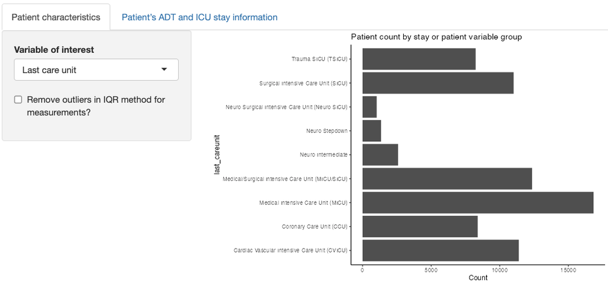

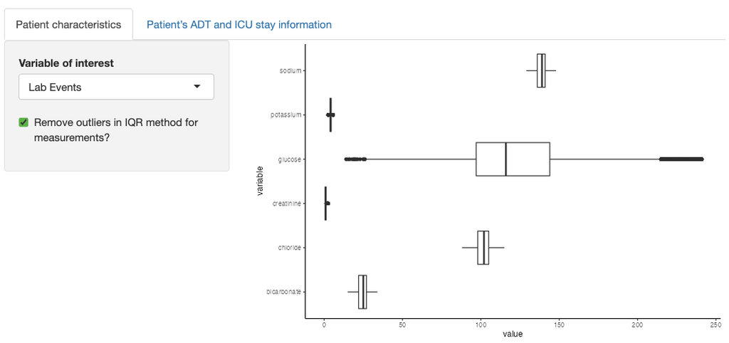

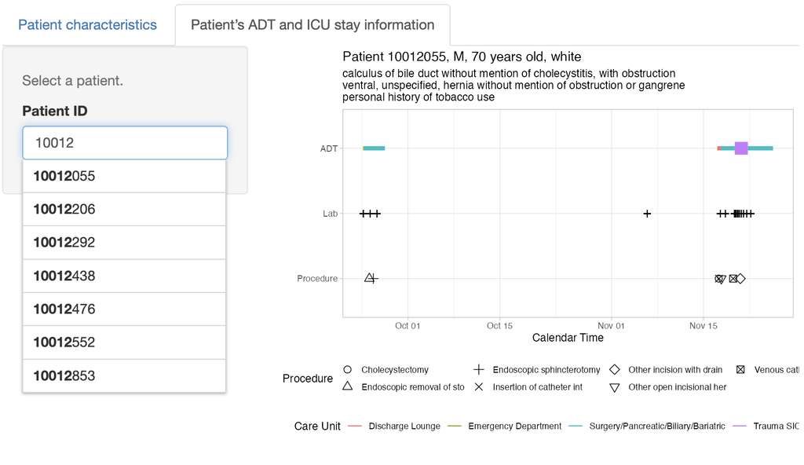